# Ejercicio evaluación de un RCT

Jorge Mantilla

2026-11-17

# 1 Caso de estudio

**Puentes Laborales** es un programa (ficticio) implementado por una organización de cooperación en ciudades de la Sierra norte del Ecuador. Está dirigido a personas migrantes adultas que llegaron al país en los últimos años y que trabajan principalmente en la economía informal.

El programa ofrece, durante tres meses:

- un curso de formación técnica corta (gastronomía, atención al cliente, oficios),
- acompañamiento para la certificación de competencias, y
- vinculación con empleadores locales.

Como había más personas interesadas (400) que cupos disponibles (200), los cupos se asignaron **por sorteo**. Esto convierte la implementación en un **ensayo controlado aleatorizado (RCT)**:

- **Grupo de tratamiento** (`tratamiento = 1`): 200 personas que recibieron el programa.
- **Grupo de control** (`tratamiento = 0`): 200 personas que no lo recibieron.

**Pregunta de evaluación:** ¿Cuál es el efecto del programa sobre el ingreso mensual de las personas participantes seis meses después de iniciado?

> **Nota:** los datos son simulados con fines didácticos.

## 1.1 Diccionario de variables

| Variable | Descripción | Momento |
| --- | --- | --- |
| `id` | Identificador de la persona | — |
| `tratamiento` | 1 = asignada al programa; 0 = grupo de control | Sorteo |
| `edad` | Edad en años | Línea de base |
| `mujer` | 1 = mujer; 0 = hombre | Línea de base |
| `anios_educacion` | Años de escolaridad aprobados | Línea de base |
| `meses_en_ecuador` | Meses de residencia en Ecuador | Línea de base |
| `num_hijos` | Número de hijos/as | Línea de base |
| `ingreso_base` | Ingreso mensual (USD) antes del programa | Línea de base |
| `ingreso_final` | Ingreso mensual (USD) seis meses después | Seguimiento (**Y**) |

En este ejercicio, la variable **X** es `tratamiento` y la variable **Y** es `ingreso_final`.

# 2 Preparación

```r
# Cargamos la base de datos
setwd("/Users/jorge/Documents/Curso-de-evaluaci-n-de-impacto-e-inferencia-causal/Ejercicios/RCT")
datos <- read.csv("EjercicioRCT.csv")

# Revisamos las primeras filas y la estructura
head(datos)
```

```
##   id tratamiento edad mujer anios_educacion meses_en_ecuador num_hijos
## 1  1           0   38     1              12               21         0
## 2  2           1   44     0              10               81         1
## 3  3           1   38     0               6               54         1
## 4  4           0   35     0              15               18         1
## 5  5           1   35     0              13               26         2
## 6  6           1   18     0              15               12         2
##   ingreso_base ingreso_final
## 1          314           310
## 2          389           655
## 3          265           379
## 4          140           275
## 5          320           423
## 6          113           292
```

```r
str(datos)
```

```
## 'data.frame':    400 obs. of  9 variables:
##  $ id              : int  1 2 3 4 5 6 7 8 9 10 ...
##  $ tratamiento     : int  0 1 1 0 1 1 1 0 0 1 ...
##  $ edad            : int  38 44 38 35 35 18 18 35 38 19 ...
##  $ mujer           : int  1 0 0 0 0 0 0 0 1 0 ...
##  $ anios_educacion : int  12 10 6 15 13 15 11 8 11 13 ...
##  $ meses_en_ecuador: int  21 81 54 18 26 12 43 41 30 49 ...
##  $ num_hijos       : int  0 1 1 1 2 2 2 1 0 1 ...
##  $ ingreso_base    : int  314 389 265 140 320 113 367 202 251 171 ...
##  $ ingreso_final   : int  310 655 379 275 423 292 592 338 275 360 ...
```

```r
# ¿Cuántas personas hay en cada grupo?
table(datos$tratamiento)
```

```
##
##   0   1
## 200 200
```

# 3 Paso 1: Comprobación de balance (pruebas t)

## 3.1 ¿Por qué comprobar el balance?

La aleatorización busca que ambos grupos sean, **en promedio, iguales antes del programa**. Si eso se cumple, cualquier diferencia posterior en `ingreso_final` puede atribuirse al programa y no a diferencias previas entre las personas.

Para comprobarlo comparamos las medias de las variables de **línea de base** entre tratamiento y control con una prueba t:

- **H0:** la media es igual en ambos grupos.
- Si el **p-valor > 0.05**, fallamos en rechazar H0 → los grupos están **balanceados** en esa variable.

> **Importante:** el balance se comprueba solo con variables medidas *antes* de la intervención. Nunca con la variable de resultado final.

## 3.2 Prueba t para una variable

Empecemos con la edad.

```r
t.test(edad ~ tratamiento, data = datos)
```

```
##
##  Welch Two Sample t-test
##
## data:  edad by tratamiento
## t = -0.67957, df = 397.4, p-value = 0.4972
## alternative hypothesis: true difference in means between group 0 and group 1 is not equal to 0
## 95 percent confidence interval:
##  -2.180044  1.060044
## sample estimates:
## mean in group 0 mean in group 1
##           32.21           32.77
```

**Instrucción:** Identifique en la salida (a) la media de cada grupo, (b) el estadístico t y (c) el p-valor.

## 3.3 Prueba t para todas las variables de línea de base

Repetir la prueba una por una es poco práctico. El siguiente código la aplica a todas las variables y resume los resultados en una tabla.

```r
# Lista de variables de línea de base
vars_base <- c("edad", "mujer", "anios_educacion",
               "meses_en_ecuador", "num_hijos", "ingreso_base")

# Aplicamos la prueba t a cada variable
balance <- lapply(vars_base, function(v) {
  prueba <- t.test(datos[[v]] ~ datos$tratamiento)
  data.frame(
    variable       = v,
    media_control  = round(prueba$estimate[1], 2),
    media_trat     = round(prueba$estimate[2], 2),
    diferencia     = round(prueba$estimate[2] - prueba$estimate[1], 2),
    p_valor        = round(prueba$p.value, 3)
  )
})

tabla_balance <- do.call(rbind, balance)
rownames(tabla_balance) <- NULL
knitr::kable(tabla_balance,
             caption = "Tabla de balance: medias por grupo y pruebas t")
```

Tabla de balance: medias por grupo y pruebas t

| variable | media_control | media_trat | diferencia | p_valor |
| --- | --- | --- | --- | --- |
| edad | 32.21 | 32.77 | 0.56 | 0.497 |
| mujer | 0.50 | 0.46 | -0.03 | 0.485 |
| anios_educacion | 10.82 | 10.83 | 0.01 | 0.973 |
| meses_en_ecuador | 28.35 | 28.76 | 0.41 | 0.794 |
| num_hijos | 1.32 | 1.25 | -0.07 | 0.512 |
| ingreso_base | 257.36 | 264.98 | 7.62 | 0.421 |

**Pregunta 1:** ¿Hay alguna variable con p-valor menor a 0.05? ¿Qué concluye sobre la aleatorización?

# 4 Paso 2: Estimación del efecto del programa (regresión)

## 4.1 Comparación simple de medias

Primero miremos el ingreso final promedio en cada grupo.

```r
aggregate(ingreso_final ~ tratamiento, data = datos, FUN = mean)
```

```
##   tratamiento ingreso_final
## 1           0        325.69
## 2           1        394.75
```

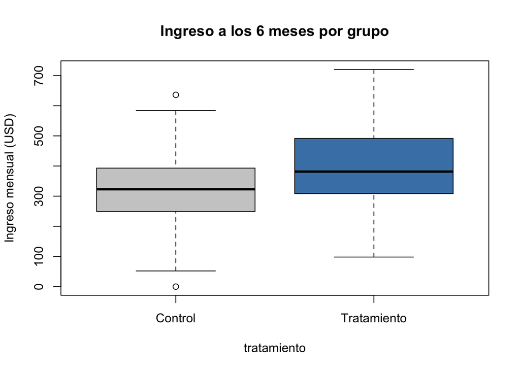

```r
boxplot(ingreso_final ~ tratamiento, data = datos,
        names = c("Control", "Tratamiento"),
        col = c("grey80", "steelblue"),
        ylab = "Ingreso mensual (USD)",
        main = "Ingreso a los 6 meses por grupo")
```

## 4.2 Modelo 1: regresión simple

En un RCT, el efecto del programa se estima con:

$$Y_i = \beta_0 + \beta_1 \,
Tratamiento_i + \varepsilon_i$$

- $\beta_0$: ingreso promedio del grupo de control.
- $\beta_1$: **efecto promedio del tratamiento (ATE)**, es decir, la diferencia de medias entre grupos.

```r
modelo1 <- lm(ingreso_final ~ tratamiento, data = datos)
summary(modelo1)
```

```
##
## Call:
## lm(formula = ingreso_final ~ tratamiento, data = datos)
##
## Residuals:
##     Min      1Q  Median      3Q     Max
## -325.69  -79.44   -8.25   83.26  325.25
##
## Coefficients:
##             Estimate Std. Error t value Pr(>|t|)
## (Intercept)  325.690      8.164  39.895  < 2e-16 ***
## tratamiento   69.060     11.545   5.982 4.92e-09 ***
## ---
## Signif. codes:  0 '***' 0.001 '**' 0.01 '*' 0.05 '.' 0.1 ' ' 1
##
## Residual standard error: 115.5 on 398 degrees of freedom
## Multiple R-squared:  0.08249,    Adjusted R-squared:  0.08018
## F-statistic: 35.78 on 1 and 398 DF,  p-value: 4.92e-09
```

**Pregunta 2:** Interprete el coeficiente de `tratamiento`. ¿En cuántos dólares cambia el ingreso por participar en el programa? ¿Es estadísticamente significativo?

## 4.3 Modelo 2: regresión con covariables

Agregar variables de línea de base **no cambia lo que se estima** (el efecto sigue siendo causal gracias al sorteo), pero suele **mejorar la precisión**, es decir, reduce el error estándar.

$$Y_i = \beta_0 + \beta_1 \,
Tratamiento_i + \gamma \, X_i^{base} + \varepsilon_i$$

```r
modelo2 <- lm(ingreso_final ~ tratamiento + edad + mujer + anios_educacion +
                meses_en_ecuador + num_hijos + ingreso_base,
              data = datos)
summary(modelo2)
```

```
##
## Call:
## lm(formula = ingreso_final ~ tratamiento + edad + mujer + anios_educacion +
##     meses_en_ecuador + num_hijos + ingreso_base, data = datos)
##
## Residuals:
##      Min       1Q   Median       3Q      Max
## -183.489  -49.472   -6.231   48.052  297.453
##
## Coefficients:
##                   Estimate Std. Error t value Pr(>|t|)
## (Intercept)       52.79939   24.03565   2.197  0.02863 *
## tratamiento       61.28897    7.34691   8.342 1.26e-15 ***
## edad              -0.50536    0.44760  -1.129  0.25957
## mujer            -34.19856    7.35717  -4.648 4.58e-06 ***
## anios_educacion    5.59104    1.28971   4.335 1.85e-05 ***
## meses_en_ecuador   0.75882    0.23225   3.267  0.00118 **
## num_hijos          1.40030    3.46670   0.404  0.68649
## ingreso_base       0.86351    0.04059  21.273  < 2e-16 ***
## ---
## Signif. codes:  0 '***' 0.001 '**' 0.01 '*' 0.05 '.' 0.1 ' ' 1
##
## Residual standard error: 73.27 on 392 degrees of freedom
## Multiple R-squared:  0.636,  Adjusted R-squared:  0.6295
## F-statistic: 97.84 on 7 and 392 DF,  p-value: < 2.2e-16
```

# 5 Conclusión

**Instrucción final:** Redacte un párrafo breve (5–6 líneas) dirigido a la organización que implementa *Puentes Laborales*, respondiendo:

1. ¿Los grupos eran comparables antes del programa?
2. ¿Cuál fue el efecto del programa sobre el ingreso mensual y qué tan preciso es?
3. ¿Qué limitaciones o preguntas adicionales tendría antes de recomendar ampliar el programa? (p. ej., deserción, cumplimiento, efectos en otros resultados, validez externa)